# Predição 02 dados de 22 abril 2021

José Elvano Moraes

4/24/2021

# Redes Bayesianas

Probabilistic reasoning on BNs works in the framework of Bayesian statistics and focuses on the computation of posterior probabilities or densities. For example, suppose we have learned a BN B with DAG G and parameters Θ. We want to use B to investigate the effects of a new piece of evidence E using the knowledge encoded in B, that is, to investigate the posterior distribution

$$P(\mathbf{X} | \mathbf{E},\mathbf{\mathcal{B}})=P(\mathbf{X} | \mathbf{E},\mathbf{G},\Theta)$$

The first step of fitting a Bayesian network is called structure learning and consists in identifying the graph structure of the Bayesian network. Ideally, it should be the minimal I-map of the dependence structure of the data or, failing that, it should at least result in a dis- tribution as close as possible to the correct one in the probability space. Several algorithms have been proposed in the literature for structure learning. Despite the variety of theoretical backgrounds and terminology, they fall under three broad cate- gories: constraint-based, score-based, and hybrid algorithms. As an alternative, the network structure can be built manually from the domain knowledge of a human expert and prior information available on the data.

he second step is called parameter learning. As the name suggests, it imple- ments the estimation of the parameters of the global distribution. This task can be performed efficiently by estimating the parameters of the local distributions implied by the structure obtained in the previous step.

Questions that can be asked are called queries and are typically an event of interest. The two most common queries are conditional probability (CPQ) and maximum a posteriori (MAP) queries, also known as most probable explanation (MPE) queries

# Fonte

URL: https://s3-sa-east-1.amazonaws.com/ckan.saude.gov.br/SRAG/2021/INFLUD21-12-04-2021.csv

```r
rm(list = ls())
# library(readr)
#  INFLUD21_12_04_2021 <- read_delim("./dados/INFLUD21-12-04-2021.csv",
#      ";", escape_double = FALSE, trim_ws = TRUE)
```

```r
###
#spec.parsing.INFLUD21_12_04_2021 <-  spec(INFLUD21_12_04_2021)
#erros.parsing.INFLUD21_12_04_2021 <- problems(INFLUD21_12_04_2021)
# save(list = c('spec.parsing.INFLUD21_12_04_2021'),
#      file = './dados/spec.parsing.INFLUD21_12_04_2021.RData', envir = .GlobalEnv)
# save(list = c('erros.parsing.INFLUD21_12_04_2021'),
#      file = './dados/erros.parsing.INFLUD21_12_04_2021.RData', envir = .GlobalEnv)
###

###
#saveRDS(INFLUD21_12_04_2021, './dados/INFLUD21_12_04_2021.rds')
INFLUD21_12_04_2021 <- readRDS('./dados/INFLUD21_12_04_2021.rds')
###
```

```r
boots.trap  <- 10


nodos <- c(  "CLASSI_FIN",
             "SEM_NOT",
             #"DT_SIN_PRI",
             #"DT_NASC",
             "TP_IDADE",
             "SG_UF_NOT",
             #"CO_MUN_RES",
             #"DT_NOTIFIC",
             "NU_IDADE_N",
             #"FEBRE",
             #"GARGANTA",
             "SATURACAO",
             #"VOMITO",
             "EVOLUCAO",
             "DIABETES",
             "OBESIDADE",
             #"CS_GESTANT",
             #"DOR_ABD",
             #"DT_EVOLUCA",
             #"CS_RACA",
             #"CS_SEXO",
             "PERD_OLFT",
             "PERD_PALA",
             #"NEUROLOGIC",
             #"FADIGA",
             #"CRITERIO",
             "PNEUMOPATI",
             "UTI",
             #"CARDIOPATI",
             "VACINA",
             "HOSPITAL",
             #"HEPATICA",
             "SUPORT_VEN"#,
             #"ASMA"#,
             #"ANTIVIRAL",
             #"IMUNODEPRE",
             #"RENAL"#,
             #"DT_INTERNA"
             )

colunas.para.inferencia <- INFLUD21_12_04_2021[,nodos]

dd<-na.omit(colunas.para.inferencia)

glimpse(dd)
```

```
## Rows: 110,076
## Columns: 16
## $ CLASSI_FIN <dbl> 4, 4, 5, 5, 4, 5, 4, 5, 5, 5, 5, 4, 5, 5, 5, 5, 4, 5, 5, 4,…
## $ SEM_NOT    <dbl> 1, 1, 2, 2, 2, 2, 2, 2, 1, 2, 2, 1, 2, 2, 2, 2, 2, 2, 2, 2,…
## $ TP_IDADE   <dbl> 3, 3, 3, 3, 3, 3, 3, 3, 3, 3, 3, 3, 3, 3, 3, 3, 3, 3, 3, 3,…
## $ SG_UF_NOT  <chr> "SP", "PR", "SP", "SP", "MG", "SP", "BA", "PR", "RJ", "SC",…
## $ NU_IDADE_N <dbl> 84, 16, 55, 81, 3, 58, 68, 57, 79, 66, 89, 39, 71, 80, 43, …
## $ SATURACAO  <dbl> 1, 1, 2, 2, 1, 1, 2, 1, 2, 2, 1, 2, 1, 2, 1, 1, 1, 1, 2, 1,…
## $ EVOLUCAO   <dbl> 1, 1, 1, 2, 1, 1, 1, 1, 1, 2, 2, 1, 1, 1, 1, 2, 2, 2, 2, 2,…
## $ DIABETES   <dbl> 1, 2, 1, 2, 2, 1, 1, 1, 2, 1, 2, 2, 2, 1, 2, 1, 2, 2, 2, 2,…
## $ OBESIDADE  <dbl> 2, 2, 2, 2, 2, 2, 2, 2, 2, 2, 2, 2, 2, 2, 2, 1, 2, 2, 2, 2,…
## $ PERD_OLFT  <dbl> 2, 2, 2, 2, 2, 2, 2, 2, 2, 2, 2, 2, 2, 2, 2, 2, 2, 2, 2, 2,…
## $ PERD_PALA  <dbl> 2, 2, 2, 2, 2, 2, 2, 2, 2, 2, 2, 2, 2, 2, 2, 2, 2, 2, 2, 2,…
## $ PNEUMOPATI <dbl> 2, 2, 2, 2, 2, 2, 2, 2, 2, 2, 2, 2, 2, 2, 2, 2, 1, 2, 2, 2,…
## $ UTI        <dbl> 2, 2, 1, 2, 1, 2, 1, 1, 2, 2, 2, 2, 2, 1, 2, 1, 2, 1, 1, 2,…
## $ VACINA     <dbl> 2, 2, 9, 9, 9, 2, 9, 9, 9, 1, 2, 1, 2, 2, 2, 2, 2, 9, 1, 2,…
## $ HOSPITAL   <dbl> 1, 1, 1, 1, 1, 1, 1, 1, 1, 1, 1, 1, 1, 1, 1, 1, 1, 1, 1, 1,…
## $ SUPORT_VEN <dbl> 2, 2, 9, 3, 2, 2, 3, 2, 2, 2, 2, 3, 2, 9, 2, 1, 1, 2, 2, 1,…
```

```r
#rm(INFLUD21_12_04_2021)
```

```r
#separar grupo de variaveis para analise

ddf <- dd %>%
  rename(IDADE = NU_IDADE_N) %>%
  filter(SG_UF_NOT == "SP") %>%
  na.omit(ddf) %>%
  filter(TP_IDADE == 3) %>%
  mutate_if(is.double,as.factor)  %>%
  mutate_if(is.character,as.factor) %>%
  select(-TP_IDADE)

  #ddf$CLASSI_FIN <- NULL
  #options(digits=2)
  ddf$IDADE = as.double(ddf$IDADE)

# discretireadR ze idade
#options(digits=2)
ddf <- discretize(ddf, method = 'interval')
#rm(dd)
ddf <- as.data.frame(ddf)
glimpse(ddf)
```

```
## Rows: 34,792
## Columns: 15
## $ CLASSI_FIN <fct> 4, 5, 5, 5, 5, 4, 5, 5, 5, 5, 5, 4, 5, 5, 4, 5, 5, 4, 5, 4,…
## $ SEM_NOT    <fct> 1, 2, 2, 2, 2, 1, 2, 2, 2, 2, 2, 3, 2, 3, 3, 3, 3, 3, 3, 4,…
## $ SG_UF_NOT  <fct> SP, SP, SP, SP, SP, SP, SP, SP, SP, SP, SP, SP, SP, SP, SP,…
## $ IDADE      <fct> "(71.6667,107]", "(36.3333,71.6667]", "(71.6667,107]", "(36…
## $ SATURACAO  <fct> 1, 2, 2, 1, 1, 2, 1, 2, 1, 1, 2, 2, 2, 1, 2, 2, 1, 1, 1, 1,…
## $ EVOLUCAO   <fct> 1, 1, 2, 1, 2, 1, 1, 1, 1, 2, 2, 1, 2, 1, 2, 1, 1, 2, 1, 1,…
## $ DIABETES   <fct> 1, 1, 2, 1, 2, 2, 2, 1, 2, 2, 2, 2, 2, 1, 2, 1, 1, 9, 2, 2,…
## $ OBESIDADE  <fct> 2, 2, 2, 2, 2, 2, 2, 2, 2, 2, 2, 2, 2, 2, 2, 2, 2, 9, 2, 2,…
## $ PERD_OLFT  <fct> 2, 2, 2, 2, 2, 2, 2, 2, 2, 2, 2, 2, 2, 2, 2, 2, 1, 2, 1, 2,…
## $ PERD_PALA  <fct> 2, 2, 2, 2, 2, 2, 2, 2, 2, 2, 2, 2, 2, 2, 2, 2, 1, 2, 1, 2,…
## $ PNEUMOPATI <fct> 2, 2, 2, 2, 2, 2, 2, 2, 2, 2, 2, 2, 2, 2, 2, 2, 2, 9, 2, 2,…
## $ UTI        <fct> 2, 1, 2, 2, 2, 2, 2, 1, 2, 1, 1, 2, 1, 2, 1, 2, 2, 2, 2, 2,…
## $ VACINA     <fct> 2, 9, 9, 2, 2, 1, 2, 2, 2, 9, 1, 1, 2, 9, 9, 1, 1, 2, 2, 1,…
## $ HOSPITAL   <fct> 1, 1, 1, 1, 1, 1, 1, 1, 1, 1, 1, 1, 1, 1, 1, 1, 1, 1, 1, 1,…
## $ SUPORT_VEN <fct> 2, 9, 3, 2, 2, 3, 2, 9, 2, 2, 2, 2, 1, 2, 1, 2, 3, 2, 1, 3,…
```

```r
#saveRDS(ddf, 'ddf.rds')
#
#  ddf <- readRDS('ddf.rds')
```

```r
nn <- nrow(ddf)

n.test <- 10000
n.learn <-  nn - n.test

ii.learn <- sample(x = 1:nn, size = n.learn, replace = FALSE)
ddf$index = 'T'
ddf$index[ii.learn] <- 'L'
table(ddf$index)
```

```
##
##     L     T
## 24792 10000
```

```r
ddf.learn <- ddf %>%
  filter(index == "L")

ddf.test <- ddf %>%
  filter(index=="T")
```

```r
s1 <- ddf.learn
s1 <- select(ddf.learn, -index, -SG_UF_NOT, -HOSPITAL)

s2 <- ddf.test
s2 <- select(ddf.test, -index, -SG_UF_NOT, -HOSPITAL)
#
```

```r
bn1 <- mmhc(s1)
```

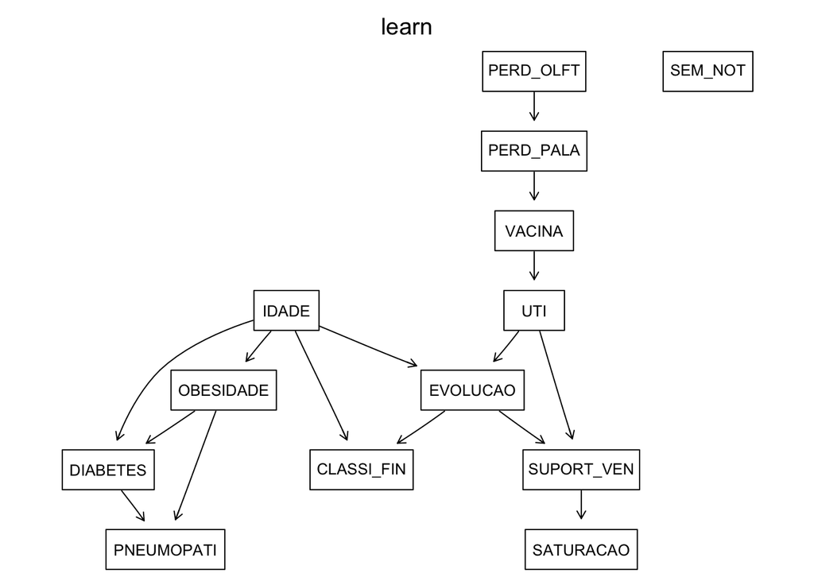

```r
par(mfrow = c(1, 1))
graphviz.plot(bn1,
              shape = 'rectangle',
              main = "learn",
              highlight  = list(mb(bn1, 'EVOLUCAO')))
```

```r
#graphviz.plot(bn2, shape = 'rectangle', main = "test")
```

# TODO

With cpquery by setting method = “lw” and specifying the evidence as a named list with one element for each node we are conditioning on

```r
wl <- matrix(c("OBESIDADE", "DIABETES",
              "IDADE", "VACINA",
              #"IDADE", "SUPORT_VEN",
              "CLASSI_FIN", "EVOLUCAO",
              "OBESIDADE", "EVOLUCAO",
              #"OBESIDADE", "EVOLUCAO",
              "PERD_OLFT", "SATURACAO",
              "SUPORT_VEN", "EVOLUCAO",
              "SATURACAO", "SUPORT_VEN",
              "IDADE","EVOLUCAO",
              "UTI", "EVOLUCAO"),
        ncol = 2, byrow = TRUE, dimnames = list(NULL, c("from", "to")))

bl <- matrix(c("OBESIDADE", "DIABETES",
               "OBESIDADE", "CLASSI_FIN",
               "CLASSI_FIN", "OBESIDADE",
               "UTI", "VACINA"),
            ncol = 2, byrow = TRUE, dimnames = list(NULL, c("from", "to")))

bn.wl.bl <- mmhc(s1, whitelist = wl, blacklist = bl)
```

## Rede black and withed listed

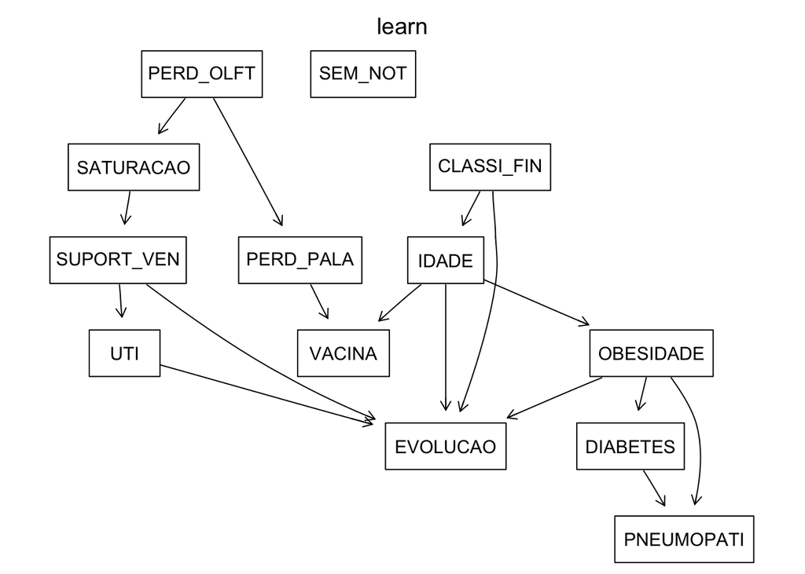

```r
par(mfrow = c(1, 1))
graphviz.plot(bn.wl.bl,
              shape = 'rectangle',
              main = "learn",
              highlight  = list(mb(bn.wl.bl, 'EVOLUCAO')))
```

## Predição

### explorar a funcao bn.boot

### bb <- bn.boot(data = s1, statistic = function(x) x, R = 10, algorithm = ‘mmhc’)

```r
bb <- bn.boot(data = s1, statistic = function(x) x, R = 10, algorithm = 'mmhc')
```

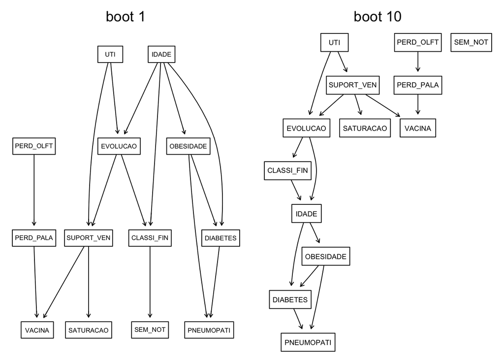

```r
par(mfrow = c(1, 2))

graphviz.plot(bb[[1]],
              shape = "rectangle",
              main = paste("boot 1"))
graphviz.plot(bb[[10]],
              shape = "rectangle",
              main = paste("boot 10"))
```

## Bootstrap REDE PADRÃO

```r
start_time <- Sys.time()
forca.real = boot.strength(s1,
                           R = boots.trap,
                           algorithm = "mmhc")


rede.media.s1 = averaged.network(forca.real)

thr.real <- paste('Thr: ', attr(forca.real, "threshold"))

delta <- Sys.time() - start_time
cat(paste("Tempo para ", boots.trap, "Bootstraps:", delta, "s"))
```

```
## Tempo para  10 Bootstraps: 2.7061939239502 s
```

## Rede “dagged”

```r
rede.media.s1.dagged <- pdag2dag(rede.media.s1,
                                   ordering = names(s1))
#rede.media.s2.dagged <- pdag2dag(rede.media.s2,
#                                    ordering = names(s2))
```

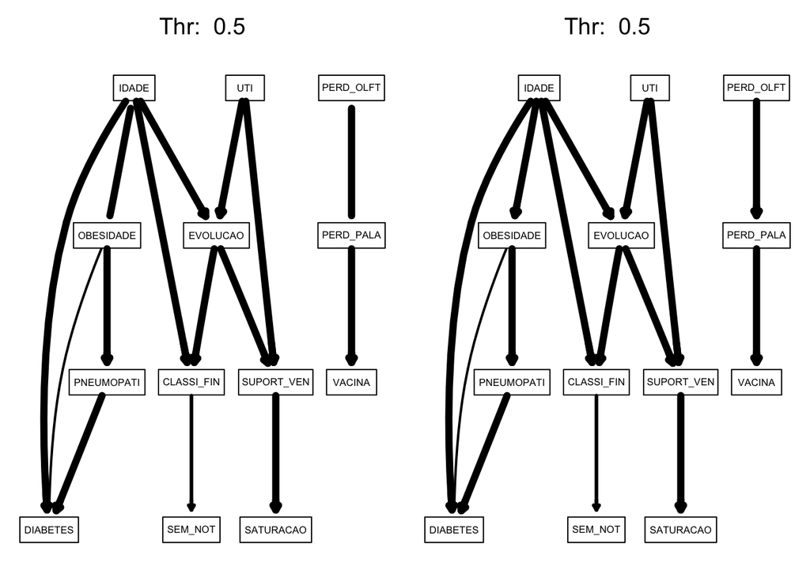

```r
par(mfrow = c(1, 2))

strength.plot(rede.media.s1,
              forca.real,
              shape = "rectangle",
              main = paste(thr.real))

strength.plot(rede.media.s1.dagged,
              forca.real,
              shape = "rectangle",
              main = paste(thr.real))
```

```r
# strength.plot(rede.media.s2,
#               forca.test,
#               shape = "rectangle",
#               main = paste(thr.test))
```

## Markov Blanket da variavel EVOLUCAO da amostra “learn”

```r
mb(x = rede.media.s1.dagged, node = 'EVOLUCAO')
```

```
## [1] "CLASSI_FIN" "IDADE"      "UTI"        "SUPORT_VEN"
```

```r
mb(x = bn1, node = 'EVOLUCAO')
```

```
## [1] "CLASSI_FIN" "IDADE"      "UTI"        "SUPORT_VEN"
```

```r
mb(x = bn.wl.bl, node = 'EVOLUCAO')
```

```
## [1] "CLASSI_FIN" "IDADE"      "OBESIDADE"  "UTI"        "SUPORT_VEN"
```

```r
mb(x = bb[[10]], node = 'EVOLUCAO')
```

```
## [1] "CLASSI_FIN" "IDADE"      "UTI"        "SUPORT_VEN"
```

# SET.EVIDENCE + QUERYGRAIN

```r
# IDADE
# (74.3333,111]     [1,37.6667]       (37.6667,74.3333]

# UTI
#  1-Sim
#  2-Nao
#  9-Ignorado

#SUPORT_VEN
# 1-Sim, invasivo
# 2-Sim, nao invasivo
# 3-Nao
# 9-Ignorado
#
# fitt1 <- bn.fit(rede.media.s1.dagged, s1)
# junction = compile(as.grain(fitt1))
# jedu = setEvidence(propagate = FALSE, junction,
#                    node = c("IDADE",
#                             "UTI",
#                             "CLASSI_FIN",
#                             "SUPORT_VEN"),
#                    states = c("[1,37.6667]",
#                               "1",
#                               "5",
#                               "3") )
# querygrain(jedu,
#            nodes = c("EVOLUCAO"),
#            type = "marginal")
```

# CPQUERY REDE *unica* SEM conhecimento especialista

## mb: “CLASSI_FIN” “IDADE” “UTI” “SUPORT_VEN”

```r
fitt.s1 <- bn.fit(bn1, s1)

prob.pred.real.1 <- cpquery(fitted = fitt.s1,
                    event = (EVOLUCAO == "1") ,
                    evidence = list(IDADE = "(36.3333,71.6667]", CLASSI_FIN = "5", SUPORT_VEN = "3",  UTI="1"),
                    method = "lw")

prob.pred.real.2 <- cpquery(fitted = fitt.s1,
                    event = (EVOLUCAO == "2") ,
                    evidence = list(IDADE = "(36.3333,71.6667]", CLASSI_FIN = "5", SUPORT_VEN = "3",  UTI="1"),
                    method = "lw")

prob.pred.real.3 <- cpquery(fitted = fitt.s1,
                    event = (EVOLUCAO == "3") ,
                    evidence = list(IDADE = "(36.3333,71.6667]", CLASSI_FIN = "5", SUPORT_VEN = "3",  UTI="1"),
                    method = "lw")

prob.pred.real.3 <- cpquery(fitted = fitt.s1,
                    event = (EVOLUCAO == "9") ,
                    evidence = list(IDADE = "(36.3333,71.6667]", CLASSI_FIN = "5", SUPORT_VEN = "3",  UTI="1"),
                    method = "lw")
###
cat ("prob DE EVOLUCAO cura.................:", prob.pred.real.1*100, "\n")
```

```
## prob DE EVOLUCAO cura.................: 76.41972
```

```r
cat ("prob DE EVOLUCAO óbito por srag.......:", prob.pred.real.2*100, "\n")
```

```
## prob DE EVOLUCAO óbito por srag.......: 22.98404
```

```r
cat ("prob DE EVOLUCAO óbito por outra causa:", prob.pred.real.3*100, "\n")
```

```
## prob DE EVOLUCAO óbito por outra causa: 0.9530677
```

# PROPORCAO NA TABELA *TEST*

```r
x <- s2 %>% filter(IDADE == "(36.3333,71.6667]",
                   CLASSI_FIN == "5",
                   SUPORT_VEN == "3",
                   UTI == "1")

nrow(x)
```

```
## [1] 101
```

```r
nrow(filter(x, EVOLUCAO=="1"))/nrow(x)*100
```

```
## [1] 83.16832
```

```r
nrow(filter(x, EVOLUCAO=="2"))/nrow(x)*100
```

```
## [1] 16.83168
```

```r
nrow(filter(x, EVOLUCAO=="3"))/nrow(x)*100
```

```
## [1] 0
```

```r
nrow(filter(x, EVOLUCAO=="9"))/nrow(x)*100
```

```
## [1] 0
```

# CPQUERY REDE **unica** COM CONHECIMENSTO DO ESPECILISTA

## mb: “CLASSI_FIN” “IDADE” “OBESIDADE” “UTI” “SUPORT_VEN”

```r
# b: "CLASSI_FIN" "IDADE"      "OBESIDADE"  "UTI"        "SUPORT_VEN"
fitt.s1.wl.bl <- bn.fit(bn.wl.bl, s1)

prob.pred.real.1 <- cpquery(fitted = fitt.s1.wl.bl,
                    event = (EVOLUCAO == "1") ,
                    evidence = list(IDADE = "(36.3333,71.6667]",
                                    OBESIDADE = "1",
                                    CLASSI_FIN = "5",
                                    SUPORT_VEN = "3",
                                    UTI="1"),
                    method = "lw")

prob.pred.real.2 <- cpquery(fitted = fitt.s1.wl.bl,
                    event = (EVOLUCAO == "2") ,
                    evidence = list(IDADE = "(36.3333,71.6667]",
                                    OBESIDADE = "1",
                                    CLASSI_FIN = "5",
                                    SUPORT_VEN = "3",
                                    UTI="1"),
                    method = "lw")

prob.pred.real.3 <- cpquery(fitted = fitt.s1.wl.bl,
                    event = (EVOLUCAO == "3") ,
                    evidence = list(IDADE = "(36.3333,71.6667]",
                                    OBESIDADE = "1",
                                    CLASSI_FIN = "5",
                                    SUPORT_VEN = "3",
                                    UTI="1"),
                    method = "lw")

prob.pred.real.9 <- cpquery(fitted = fitt.s1.wl.bl,
                    event = (EVOLUCAO == "9") ,
                    evidence = list(IDADE = "(36.3333,71.6667]",
                                    OBESIDADE = "1",
                                    CLASSI_FIN = "5",
                                    SUPORT_VEN = "3",
                                    UTI="1"),
                    method = "lw")
###

cat ("prob DE EVOLUCAO cura.................:", prob.pred.real.1*100, "\n")
```

```
## prob DE EVOLUCAO cura.................: 75.26802
```

```r
cat ("prob DE EVOLUCAO óbito por srag.......:", prob.pred.real.2*100, "\n")
```

```
## prob DE EVOLUCAO óbito por srag.......: 25.17411
```

```r
cat ("prob DE EVOLUCAO óbito por outra causa:", prob.pred.real.3*100, "\n")
```

```
## prob DE EVOLUCAO óbito por outra causa: 0
```

```r
cat ("prob DE EVOLUCAO óbito por outra causa:", prob.pred.real.9*100, "\n")
```

```
## prob DE EVOLUCAO óbito por outra causa: 0
```

# PROPORCAO NA TABELA *TEST*

```r
x <- s2 %>% filter(IDADE == "(36.3333,71.6667]",
                   OBESIDADE == "1",
                   CLASSI_FIN == "5",
                   SUPORT_VEN == "3",
                   UTI == "1")

nrow(x)
```

```
## [1] 17
```

```r
nrow(filter(x, EVOLUCAO=="1"))/nrow(x)*100
```

```
## [1] 88.23529
```

```r
nrow(filter(x, EVOLUCAO=="2"))/nrow(x)*100
```

```
## [1] 11.76471
```

```r
nrow(filter(x, EVOLUCAO=="3"))/nrow(x)*100
```

```
## [1] 0
```

```r
nrow(filter(x, EVOLUCAO=="9"))/nrow(x)*100
```

```
## [1] 0
```

### Desempenho estatístico da rede

[output not shown]

[output cut: 7985 more lines]

```r
# b: "CLASSI_FIN" "IDADE"      "OBESIDADE"  "UTI"        "SUPORT_VEN"

fitt <- bn.fit(bn.wl.bl, s1)
prob.pred.cpq <- c()


for (ii in c(1:nrow(nodos))) {
prob.pred.cpq[ii] <- cpquery(fitted = fitt,
                    event = (EVOLUCAO == "2") ,
                    evidence = list(CLASSI_FIN = as.character(nodos[ii,1]),
                                    IDADE = as.character(nodos[ii,2]),
                                    OBESIDADE = as.character(nodos[ii,3]),
                                    UTI = as.character(nodos[ii,4]),
                                    SUPORT_VEN = as.character(nodos[ii,5])),
                    method = "lw")
}
```

[output not shown]

### Curva ROC

[figure not shown]

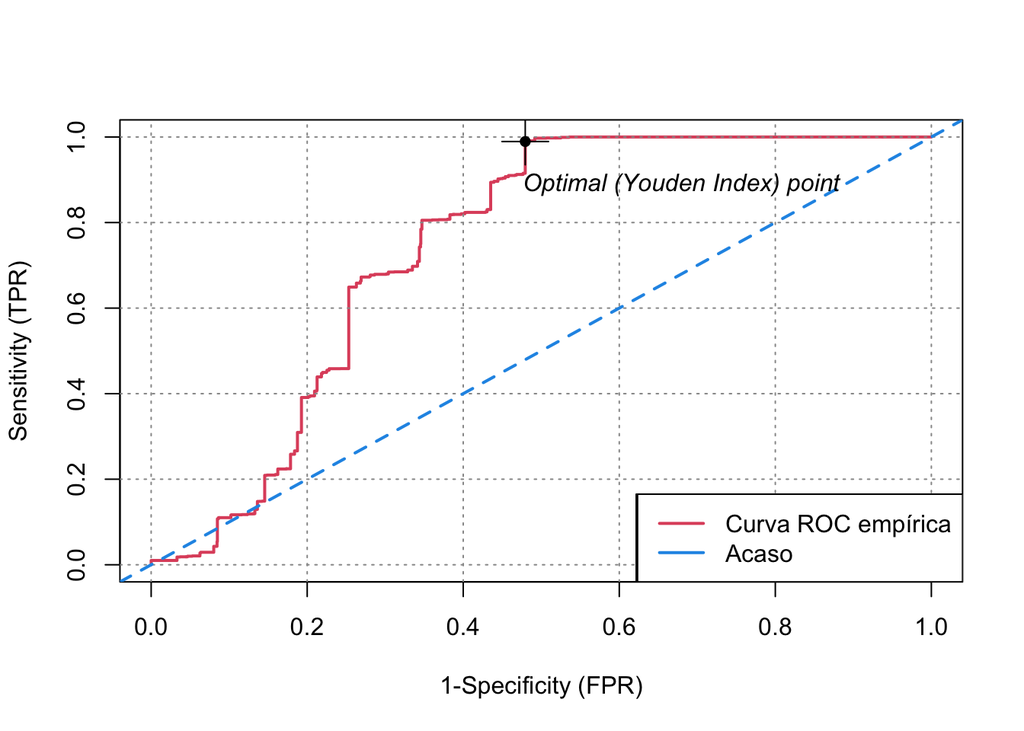

```
##
##  Method used: empirical
##  Number of positive(s): 5856
##  Number of negative(s): 2144
##  Area under curve: 0.7426
##
## 1      Method used: empirical
## 2 Number of positive(s): 5856
## 3 Number of negative(s): 2144
## 4    Area under curve: 0.7426
```

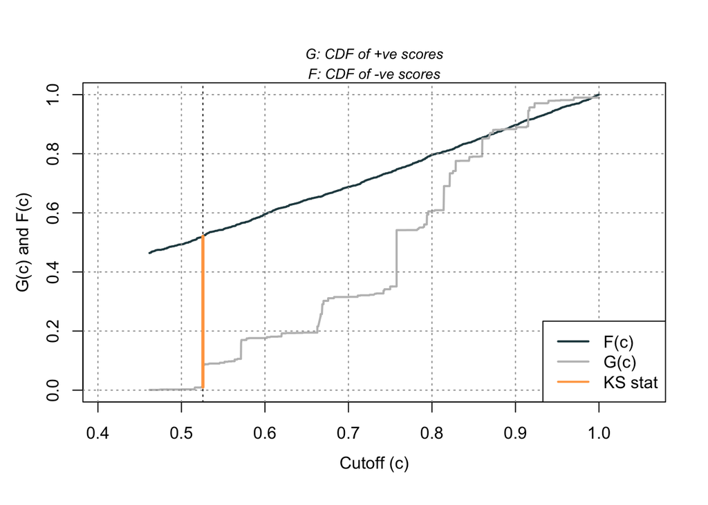

```
## KS Stat (empirical) : 0.509934956365712
```

```
## KS Stat (empirical) cutoff : 0.52573673870334
```